# RaceReport

## Fantasy League Scores

Scores for drivers/constructors in the current year's fantasy league, along with manager/team points, values, and statistics. Note: driver and constructor values are taken as the cost to enter the current race and are updated the week before the race.

## Lineup Scores

Oscar Piastri takes the Grand Prix victory and the weekly top score this week with a commanding lead over Nico Hulkenberg, the pair coming in with 45 and 32 points respectively. Lando Norris pips Charles Leclerc to third with 28 points, the Ferrari man only managing 27. George Russell rounds out the top five with 21 points. Lance stroll comes home with -20 points this week for his DNS, behind Alex Albon who suffers his worst weekend of the season with -18 points. Kimi Antonelli's second retirement of the season is met with -12 points, behind Oliver Bearman who comes home with a big fat 0. Esteban Ocon rounds out the bottom five and a disappointing weekend for Haas with 3 points.

McLaren come away from Spain with yet another weekly top score, the papaya team bringing home 88 points ahead of Ferrari with 61 and Kick Sauber, who get their best weekend of the season with 52 points. I bet that messed up a lot of Golf teams. Williams are your worst team of the week with -8 points, behind Aston Martin with 1. Haas round out the bottom three with 6 points.

Lando's lead over teammate Piastri at the top of the standings is coming down little by little. The Brit leads the Aussie 354 to 319 points. Reigning Champion Max Verstappen is in third, with a distant 259 points ahead of George Russell with 194. Lewis Hamilton sits in fifth still ahead of his teammate with 156 points. Fernando Alonso is still at the bottom of the table, with -35 points, behind Gabriel Bortoleto with -12 points. Pierre Gasly sits on 0 behind new teammate Colapinto with 11. Sainz and Lawson round out the bottom five with 17 points.

McLaren, unsurprisingly, top the table with 792 points, ahead of Ferrari with 439 points and Mercedes with 388. Alpine are still at the bottom of the table with 45 points, as Aston Martin drop down the order with 67. A great weekend for Kick Sauber see them rounding out the bottom three with 84 points.

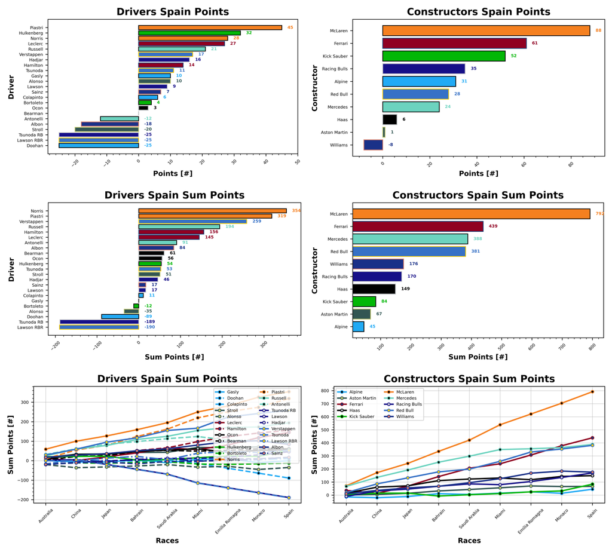

McLaren were your most expensive team this week at 32.4, ahead of Ferrari and Red Bull at 28.5 and 27.2. Kick Sauber were your cheapest team of the week at 5.7, behind Alpine at 7.1 and Aston Martin at 9.3.

All values are in Million Dollars.

Colapinto is your worst driver of the season so far, scoring positively only 22.22% of the time. Your strongest four drivers of the season are Verstappen, Russell, Piastri, and Norris who have all scored positively in every single race. That level of consistency is matched by their respective constructors with Red Bull, Mercedes and McLaren scoring positively in each race. Alpine are by far the worst team of the season, scoring positively 55.56% of the time.

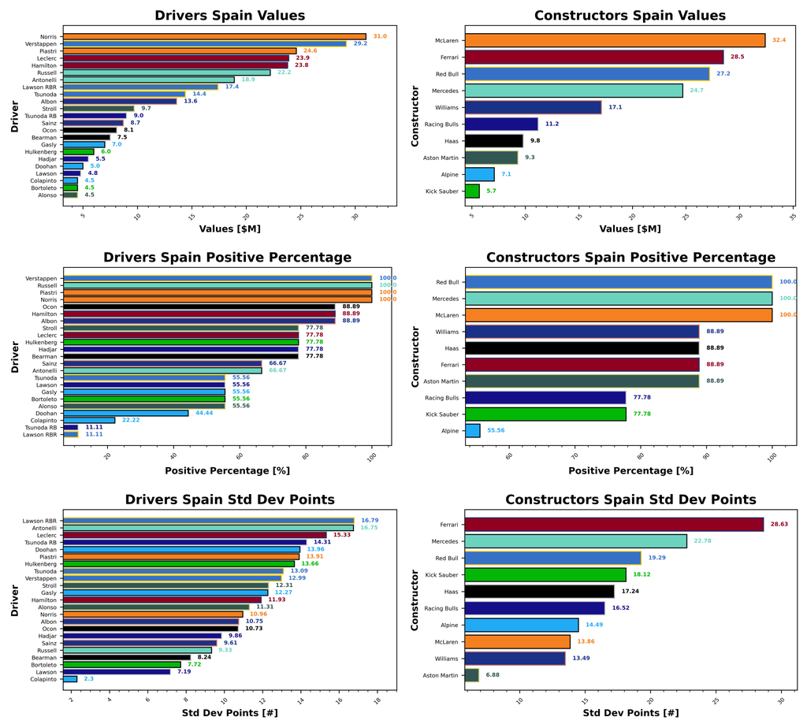

Colapinto might not be scoring positively all the time, but he is consistent, having a standard deviation of 2.3. Lawson and Bortoleto are also up there with consistency. Your least consistent drivers are Antonelli and Leclerc, who have a huge variation in their average scores. Aston Martin are your most consistent team of the season so far, with Ferrari your least consistent team, with massive variation in their average score.

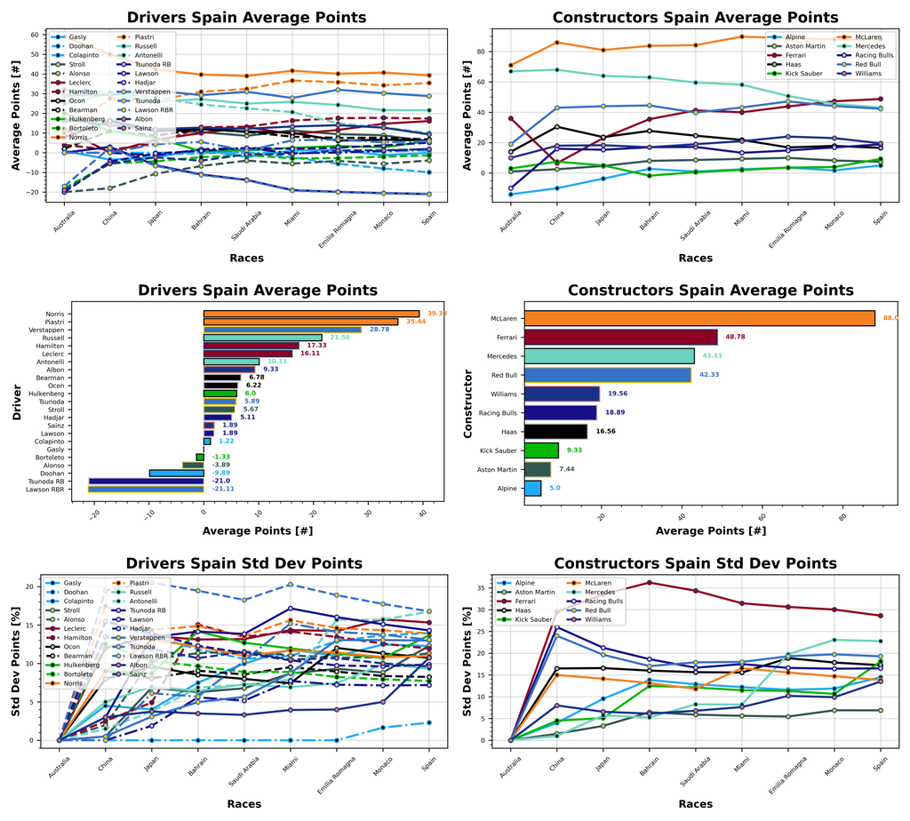

With a stunning points finish, Nico Hulkenberg is your driver of the week this week with a points per value of 5.33 ppm. He's leaps ahead of rookie of the year, so far, Isack Hadjar with 2.91 ppm. Alonso's first points finish brings him a third place with 2.22 ppm. Lawson and Piastri round out the top five with 1.88 and 1.83 ppm, respectively. Lance Stroll was the worst driver of the week with -2.06 ppm, behind Alex Albon with -1.32 ppm. Kimi Antonelli is next with -0.63 ppm. behind Bearman with 0 ppm. Esteban Ocon rounds out the bottom five with 0.37 ppm.

Team of the week, this week, and it's not even a competition, was Kick Sauber with 9.12 ppm. Alpine are next with 4.37 ppm, ahead of Racing Bulls with 3.12 ppm. Your worst team of the week was Williams with -0.47 ppm, behind Aston Martin with 0.11 ppm and Haas with 0.61 ppm.

ppm = points per million Dollars.

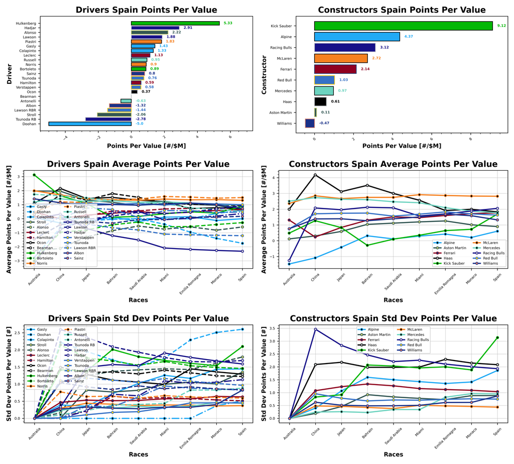

### Manager Scores

Another victory this week for Stefanus and Gelael who pip Jake and Kick Sauber In The Audi by 1 point, the pair coming in with 294 and 293 points respectively. Patrick and You Hadjar Chance Racing are in third with 283 points ahead of Stefanus and Syahrul with 270. Pete and Monaco Barrier Testers round out the top five this week with 244.

Valerie and Stroll To The 18th and What Arrrgh Ya Doohan were your worst teams of the week this week, bringing home 28 points. Will and The Big One are in second with 37, ahead of Pete and Seagiant F1 Online with 52. Valerie and Perez For World Champion are next with 54 points, followed by Stuart and Taylormade To Lose with 62.

Stefanus was our manager of the week this week with 267 points across their team. Jake makes a rare appearance in second with 185.33. Patrick is next with 185 across their teams. Valerie was your worst manager of the week with 36.67 points across their teams, with Finn in second with 83. Will rounds out the bottom three with 90.33 points.

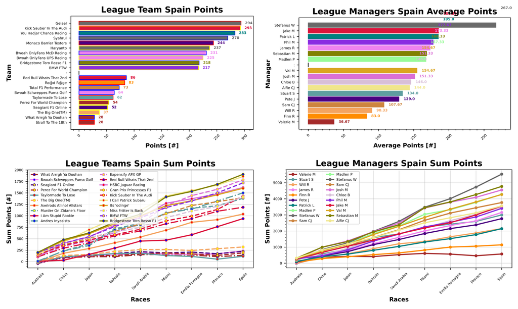

Stefanus and Syahrul move into the lead this week with 1903 points ahead of Alfie and I Call Patrick Subaru with 1901. Sebastian and Bridgestone Toro Rosso F1 drop down to third with 1891 points, ahead of Stefanus and Haryanto with 1852. Josh and Expensify APX GP round out the top five with 1785 points.

Stuart moves into the lead of the Golf League with Taylormade To Lose and 116 points. Alfie sits in second with Cucumberpotatolamborghini with 127 points. Valerie is in third and fourth with What Arrrgh Ya Doohan and Perez For World Champion with 168 and 174 points. Pete rounds out the bottom five with Seagiant F1 Online and 224 points.

Our biggest winner this week was Jake with Kick Sauber In The Audi with 5 places gained. Our biggest loser is Sam with Grand Prix Princesses F1 dropping 4 places.

Stefanus holds on to the lead in the average manager points for the season, sitting on 1844.67, ahead of Sebastian with 1582.67, and Josh with 1535.67. Valerie is our worst manager of the season with 200 points, behind Will with 716.33 and Pete with 923.

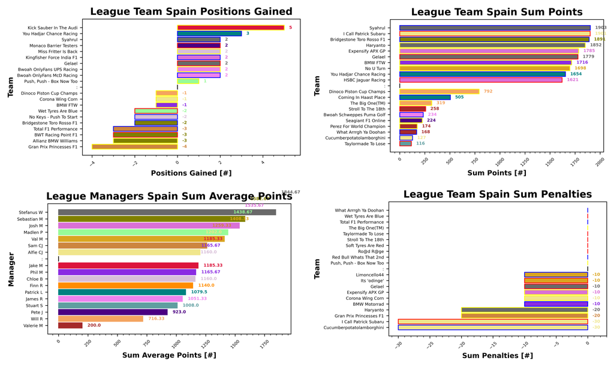

Hadjar continues his stranglehold over your interests this week, making 34 selections. Oscar Piastri is some way behind with 23, followed by Albon and Alonso with 18, Bearman with 17, and Colapinto and Hulkenberg with 16.

There's still a Lawson Red Bull token kicking around, but it's Yuki Tsunoda who is the least selected live driver, with 1 selection. Then it's Verstappen and Hamilton with 2 selections. Then it's Yuki Tsunoda's RB token with 3 behind Kimi Antonelli with 5 selections in fifth.

McLaren, Haas, and Kick Sauber are your three teams of choice, with 20, 18, and 11 selections each. Mercedes only makes 3, with Alpine just ahead with 4 selections, and Red Bull rounding out the bottom three with 5.

Oscar Piastri is boosted 22 times, ahead of Bortoleto with 5 a piece. Norris, Leclerc and Doohan are all boosted 4 times. We only have one token in use this week, and that's an Auto Pilot.

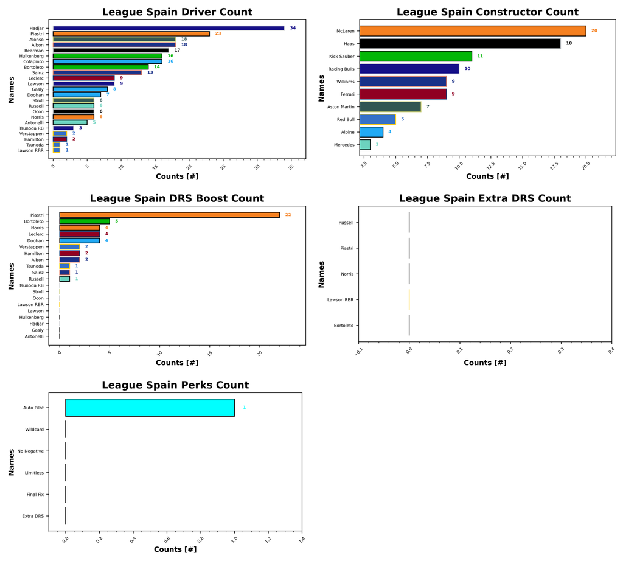

## Prizes

I have now updated the prizes plotting for my code and we should be able to track the season long prizes with ease. So without further adieu, let's take a look at what is currently in play this season.

### Championship

| Prize Name | Prize Value | Terms |
| --- | --- | --- |
|  | (%) |  |
| Champion of the World | 20 | Awarded to the top scorer in the league at the end of the season |
| If You're Not First, You're Last | 10 | Awarded to the second place scorer in the league at the end of the season |
| Alpine Podium | 5 | Awarded to the third place scorer in the league at the end of the season |
| Above Par | 20 | Awarded to the lowest scorer in the league at the end of the season, commonly referred to as the Golf League |

### Achievements

| Prize Name | Prize Value | Terms |
| --- | --- | --- |
|  | (%) |  |
| Cost Cappen | 5 | Highest average points per value at the end of the season |
| Sprint King | 5 | Highest score across the sprint races (China, Miami, Belgium, United States, Brazil, Qatar) |
| Flavio Controls Every Millimeter | 5 | Manager wide substitution count, highest wins |
| The Triple Header | 5 | Highest score across the triple header races (Japan, Bahrain, Saudi Arabia, Emilia Romagna, Monaco, Spain, Las Vegas, Qatar, Abu Dhabi) |
| I Forgot I Was Taking Part | 5 | Highest score in the first part of the season |
| Zak's Master Plan | 5 | Lowest score in the second half of the season |
| Mega Driver | 5 | Highest Extra DRS token score |
| The Continental | 5 | Highest score across all 5 continents, Mexico classed as South America for inclusion only (Australia, Canada, Great Britain, Azerbaijan, Mexico) |

### Spot Prizes

| Prize Name | Prize Value | Terms |
| --- | --- | --- |
|  | (%) |  |
| The Ring | 1 | Highest score at the Austrian Grand Prix |
| Bottas Bowling | 1 | Highest score at the Hungarian Grand Prix |
| Daniel's Broken Hand | 1 | Lowest score at the Netherlands Grand Prix |
| The Tifosi | 1 | Lowest score at the Italian Grand Prix |
| Go For The Gap | 1 | Lowest score at the Singapore Grand Prix |

### Spot Prizes

We haven't had a spot prize yet, I will post about it when we have one!

### Cost Cappen

We have a new leader this week as Alfie and I Call Patrick Subaru move into the top with 2.10 ppm, ahead of Sebastian and Bridgestone Toro Rosso F1 with 2.09 ppm. Stefanus and Syahrul are in third with 2.06 ppm.

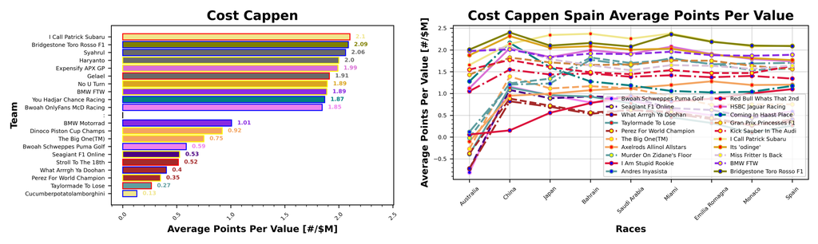

### Flavio Controls Every Millimeter

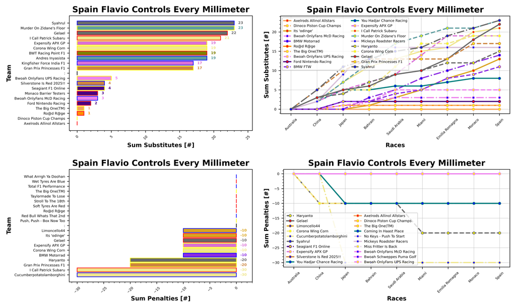

### Mega Driver

Check back later!

### Sprint King

No Change. Sebastian is in the lead with Bridgestone Toro Rosso F1 and 652 points, ahead of Josh with Expensify APX GP and HSBC Jaguar Racing with 622 and 591 points.

```
No images found for Sprint King for Spain.
```

[figure not shown]

### The Continental

No update here, but Sebastian is leading the way with Bridgestone Toro Rosso F1 and 201 points, ahead of Phil with BMW FTW and 198 points. Chloe is in third with Miss Fritter Is Back and 197 points.

[output not shown]

[figure not shown]

### The Triple Header

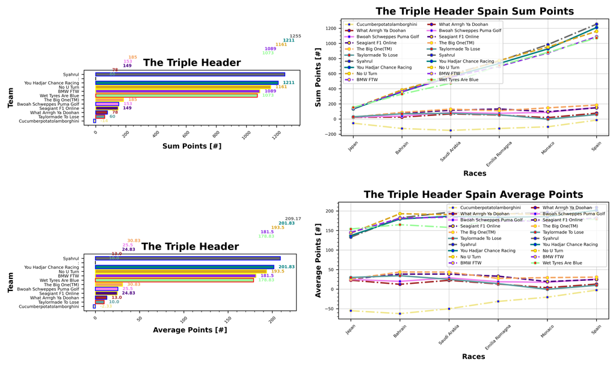

### I Forgot I Was Taking Part

I Forgot I Was Taking Part will match up with the current championship standings. Syahrul (1903), I Call Patrick Subaru (1901), and Bridgestone Toro Rosso F1 (1891).

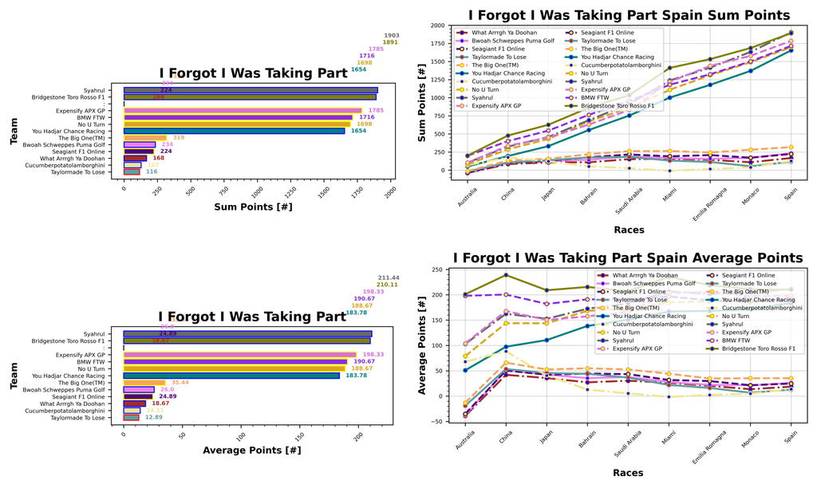

### Zak's Master Plan

Check back after the season break!

## F1 Predict

Josh took the honours this week with 82 points (47%) ahead of Val with 56 (33%). Stuart was in third with 53 points (37%) ahead of Phil with 44 (27%). Pierce and Matty both come away with 0.

Stuart holds on to the lead with 517 points (50%), ahead of Phil with 452 (43%). Val is in third with 413 points (44%), ahead of Josh in fourth with 409 points (30%). Pierce is in fifth with 248 points (45%), and Matty rounds out the field with 95 points (43%).